# Prediction Models - Iteration 3

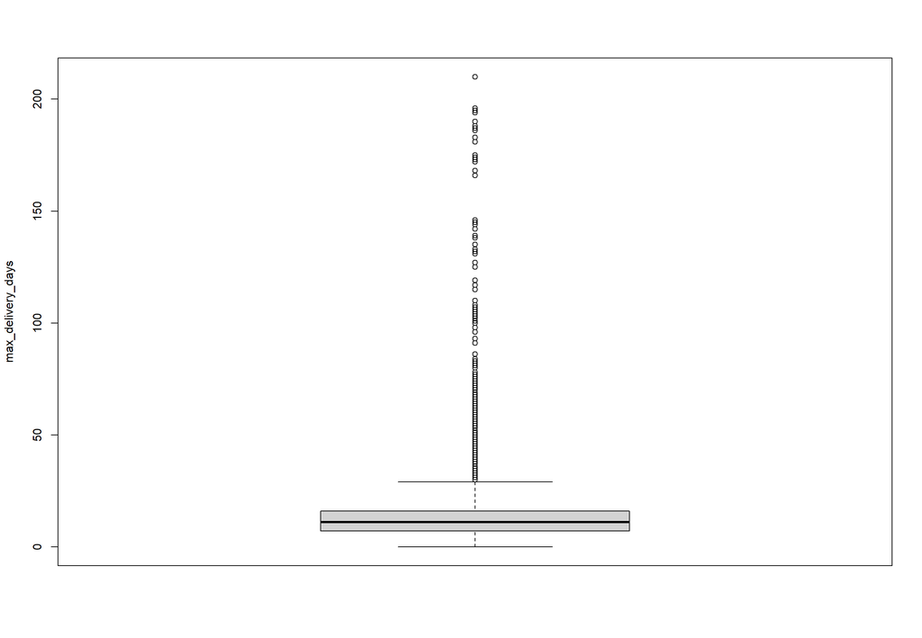

```r
boxplot(fct_features$max_delivery_days,
  ylab = "max_delivery_days")
```

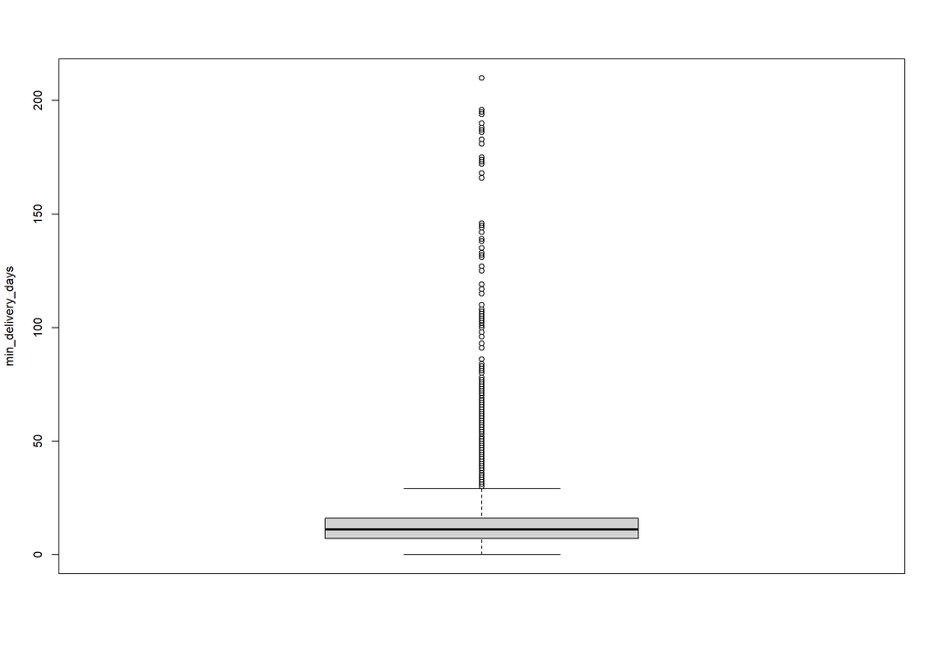

```r
boxplot(fct_features$min_delivery_days,
  ylab = "min_delivery_days")
```

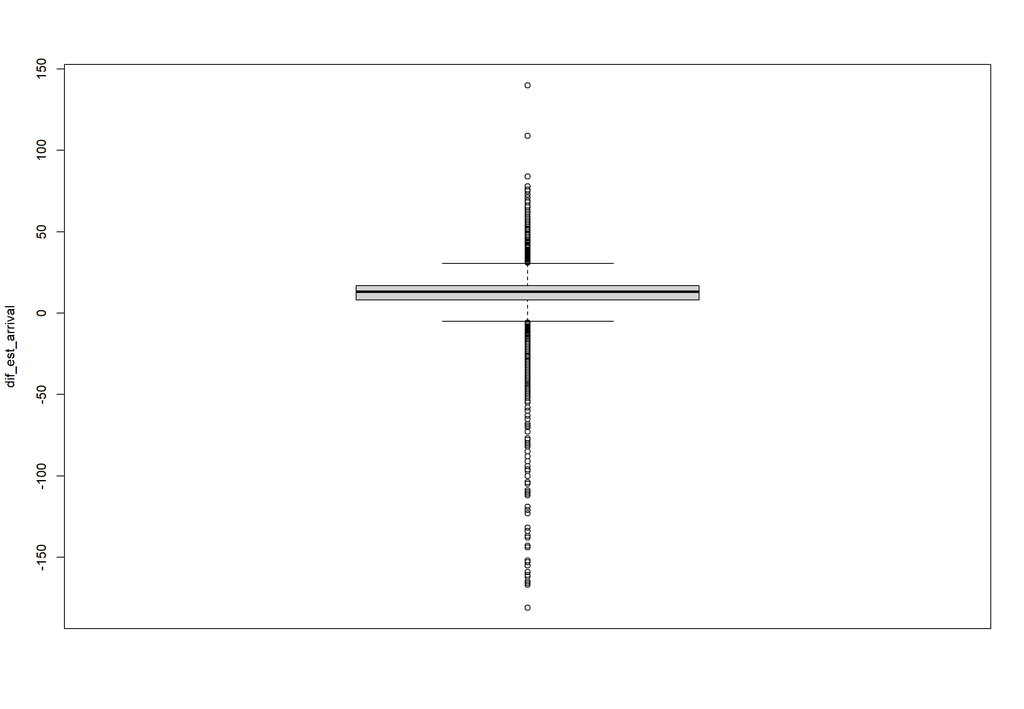

```r
boxplot(fct_features$dif_est_arrival,
  ylab = "dif_est_arrival")
```

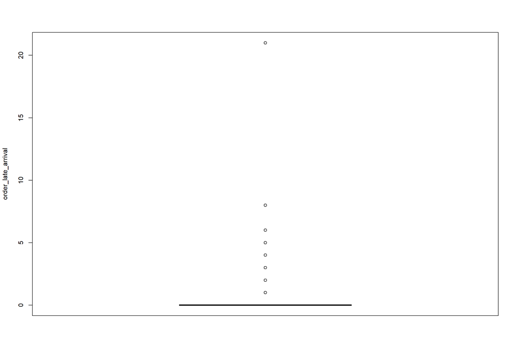

```r
boxplot(fct_features$order_late_arrival,
  ylab = "order_late_arrival")
```

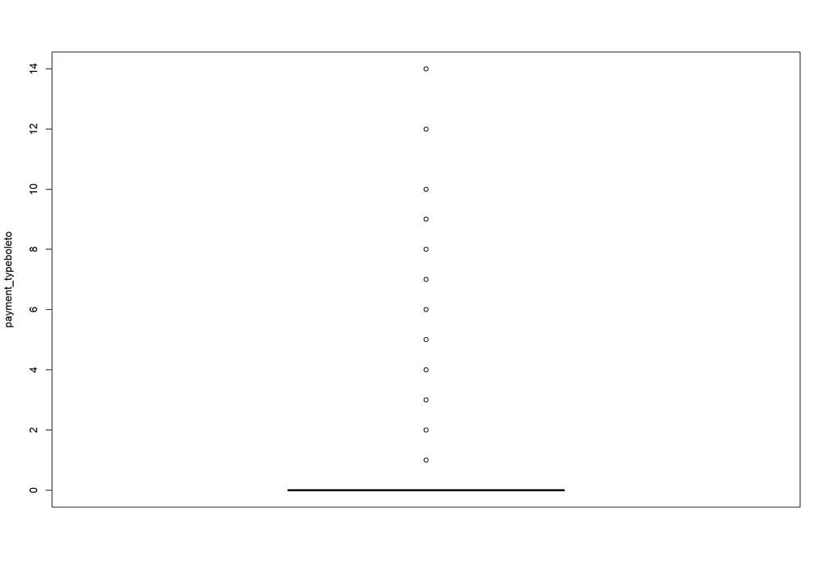

```r
boxplot(fct_features$payment_typeboleto,
  ylab = "payment_typeboleto")
```

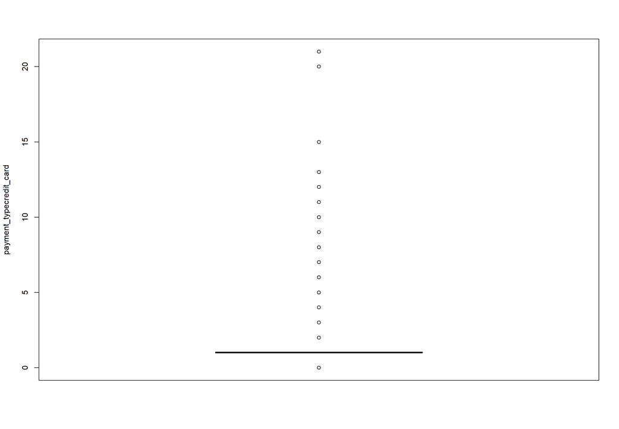

```r
boxplot(fct_features$payment_typecredit_card,
  ylab = "payment_typecredit_card")
```

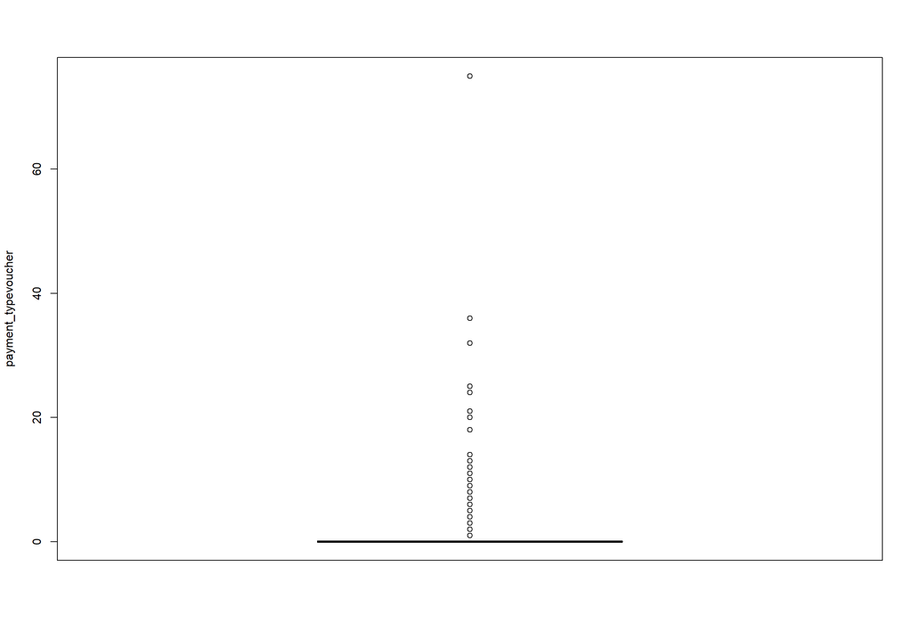

```r
boxplot(fct_features$payment_typevoucher,
  ylab = "payment_typevoucher")
```

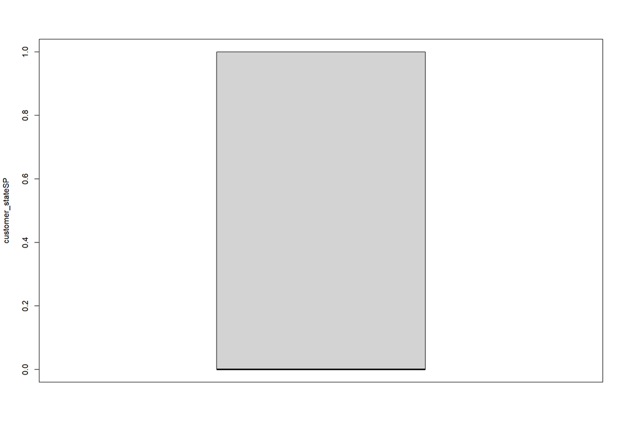

```r
boxplot(fct_features$customer_stateSP,
  ylab = "customer_stateSP")
```

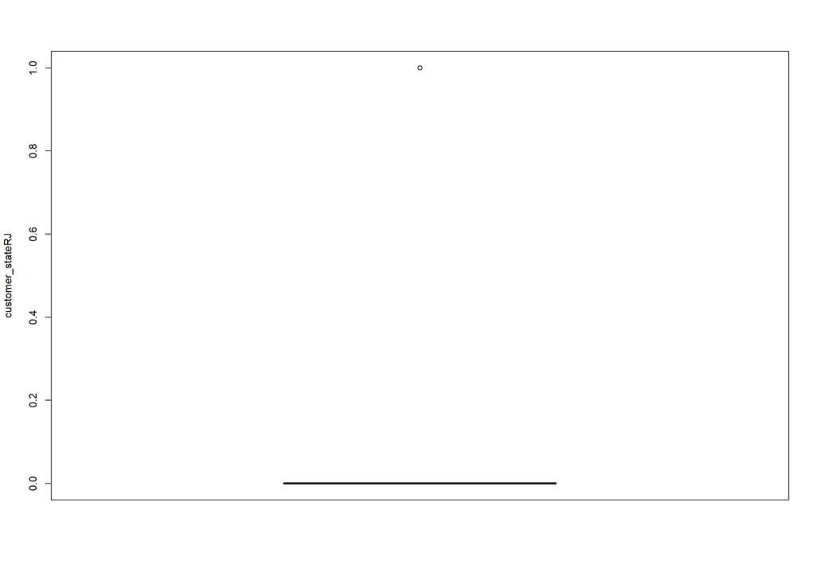

```r
boxplot(fct_features$customer_stateRJ,
  ylab = "customer_stateRJ")
```

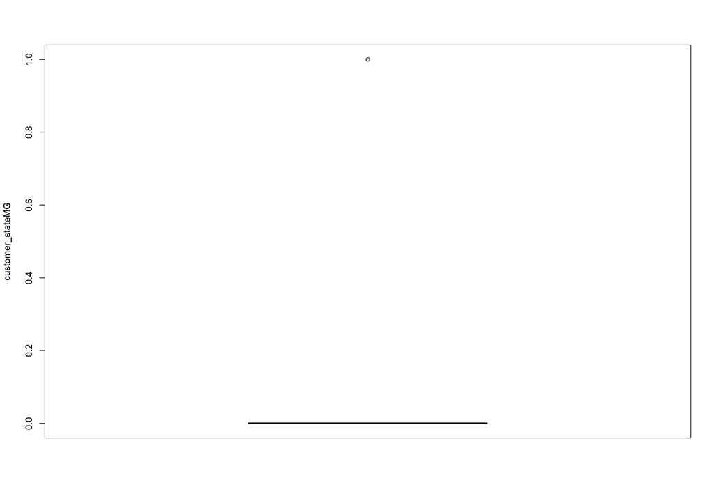

```r
boxplot(fct_features$customer_stateMG,
  ylab = "customer_stateMG")
```

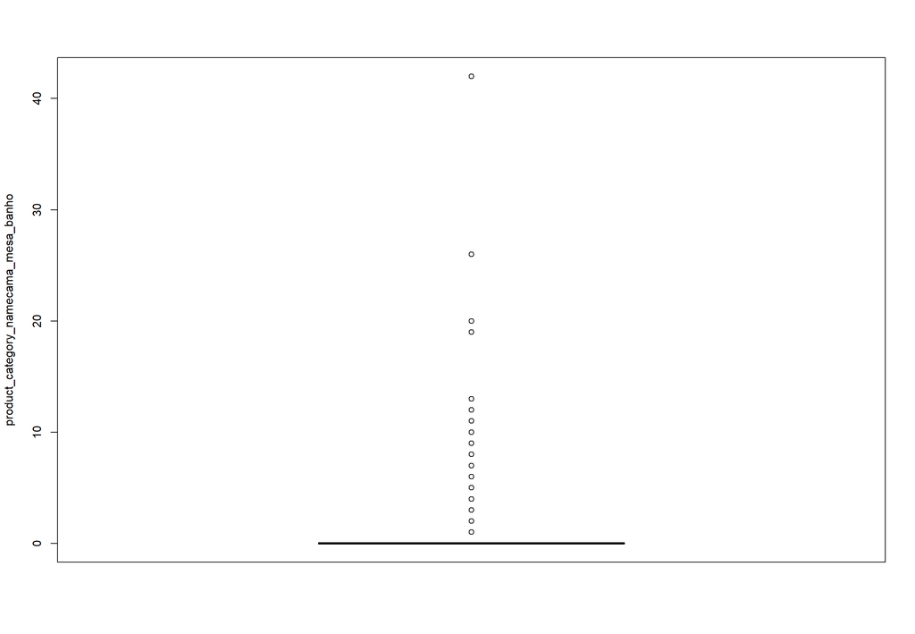

```r
boxplot(fct_features$product_category_namecama_mesa_banho,
  ylab = "product_category_namecama_mesa_banho")
```

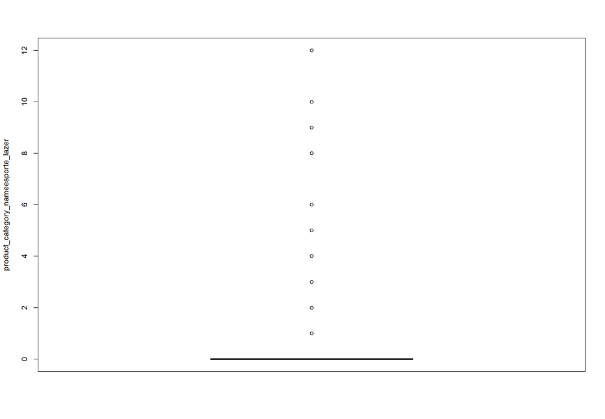

```r
boxplot(fct_features$product_category_nameesporte_lazer,
  ylab = "product_category_nameesporte_lazer")
```

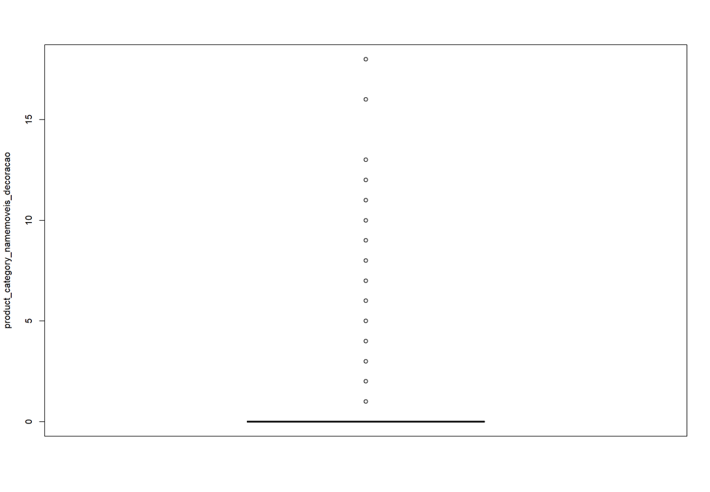

```r
boxplot(fct_features$product_category_namemoveis_decoracao,
  ylab = "product_category_namemoveis_decoracao")
```

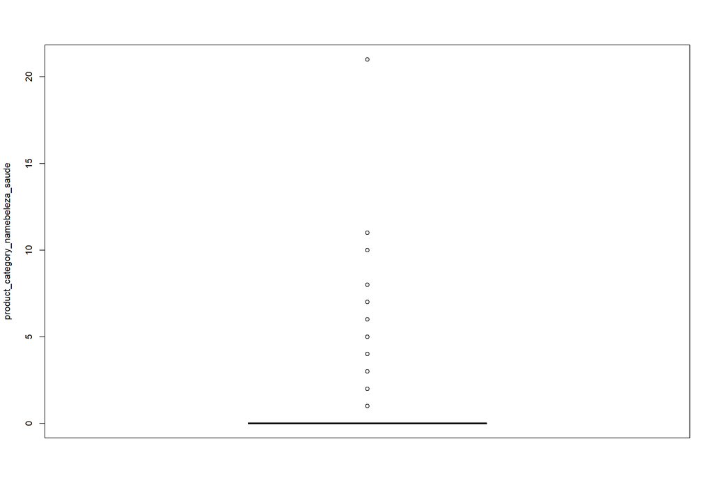

```r
boxplot(fct_features$product_category_namebeleza_saude,
  ylab = "product_category_namebeleza_saude")
```

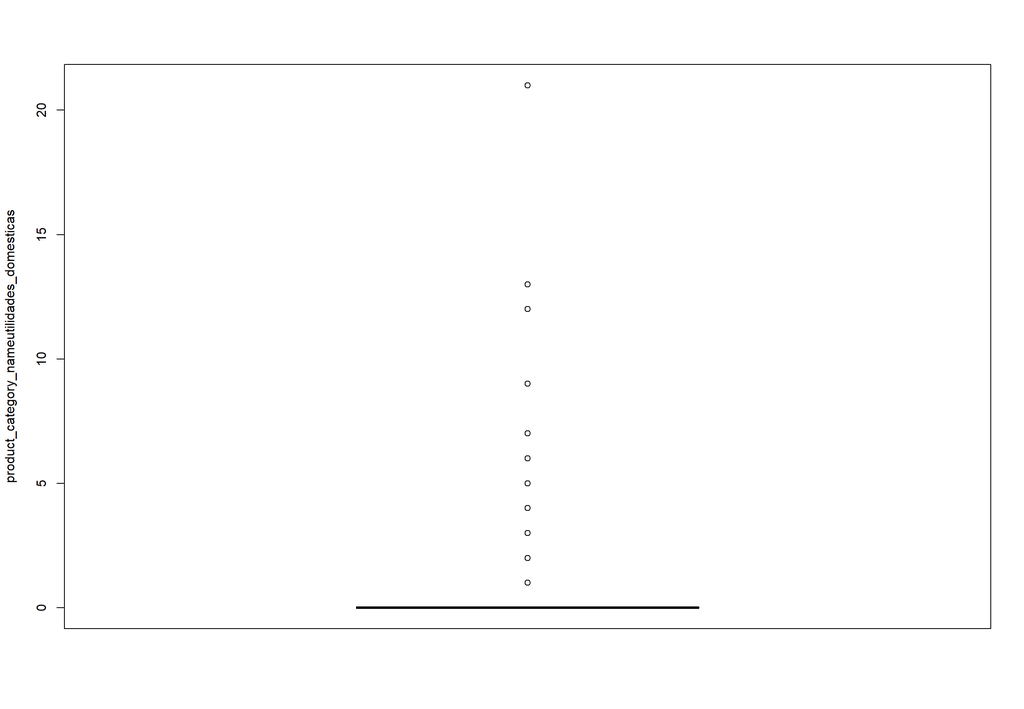

```r
boxplot(fct_features$product_category_nameutilidades_domesticas,
  ylab = "product_category_nameutilidades_domesticas")
```

**Comments:** Few outliers were found for discretized features as well as features resulting from one hot encoding. The other features had an high number of outliers

### 3.5. Correlations

#### 3.5.1. fct_features

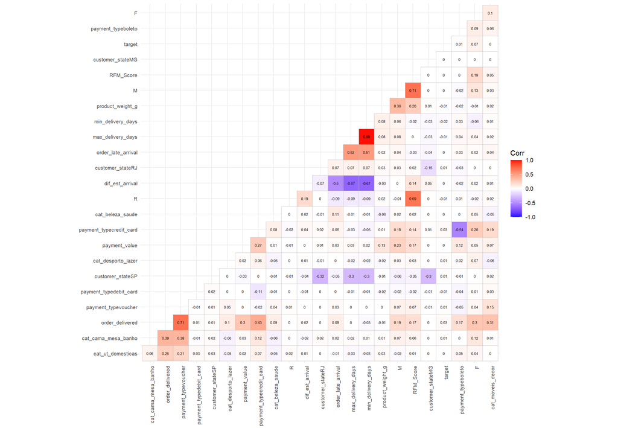

```r
# Rename features with long names
fct_features <- fct_features %>% dplyr::rename(cat_ut_domesticas = product_category_nameutilidades_domesticas, cat_beleza_saude = product_category_namebeleza_saude, cat_moveis_decor = product_category_namemoveis_decoracao, cat_desporto_lazer = product_category_nameesporte_lazer, cat_cama_mesa_banho = product_category_namecama_mesa_banho)

# Compute a correlation matrix
corr <- round(cor(fct_features[,-1]),2)

# Visualize the correlation matrix
ggcorrplot(corr, hc.order = TRUE, type = "lower",
   lab = TRUE,
   lab_size = 2,
   tl.cex = 8,
   tl.srt = 90)
```

**Comments:** . Correlation was found between order_delivered and payment_typevoucher features. payment_typevoucher was therefore removed. . Correlation was found between dif_est_arrival and both max_delivery_days and min_delivery_days features. dif_est_arrival was therefore removed. . Correlation was found between max_delivery_days and min_delivery_days features. min_delivery_days removed. . Correlation was found between RFM_Score and both Recency and Monetary features. RFM_Score was therefore removed. . Remaining features can be used for ML.

# 4. Define train and test sets for ML models

### 4.1. Define levels for target

```r
# Define features to remove, including customer unique id
columns_to_remove <- c(1, 6, 11, 12, 17)

# Define custom levels and remove RFM_Score feature
fct_features <- fct_features[,-columns_to_remove] %>% mutate(target = ifelse(target == "0", "not_returned", "returned"))

# Convert integer column to factor
fct_features$target <- factor(fct_features$target)
```

### 4.2. Define train and test sets ———————————————-

```r
# Holdout a validation set, by defining the indices of the training set

seed <- 12345

set.seed(seed)
train_index <- createDataPartition(fct_features$target, p = 0.8, list = FALSE)

train_set <- fct_features[train_index, ]
test_set  <- fct_features[-train_index, ]

# get a prob table between customers who returned vs not returned
prop.table(table(train_set$target))
```

```
##
## not_returned     returned
##   0.98439578   0.01560422
```

**Comments:** we see that only 1.6% of the customers returned (high imbalanced data)

# 5. Create DT

### 5.1. Fit Decision Tree model

```r
#' Model Decision Tree from Rpart (Recursive Partitioning and Regression Trees)
model_tree <- rpart(target ~ ., data = train_set)
print(model_tree)
```

```
## n= 33837
##
## node), split, n, loss, yval, (yprob)
##       * denotes terminal node
##
## 1) root 33837 528 not_returned (0.98439578 0.01560422) *
```

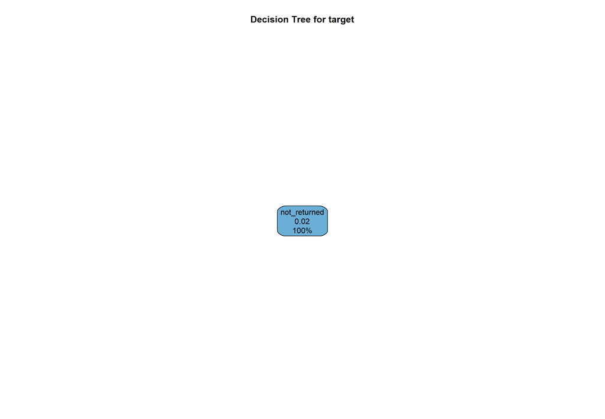

```r
#' View decision tree
rpart.plot(model_tree,
           main = "Decision Tree for target")
```

**Comments:** . DT has only one node (root node), which predicts the outcome “not_returned” for all observations. . This is a result of the highly imbalanced data.

### 5.2. Validate results with a Confusion Matrix

```r
# Validate results with a Confusion Matrix --------------------------------

#' Calculate model predictions on TEST set
prediction.dt <- predict(model_tree,
                         test_set,
                         type = "class")
head(prediction.dt)
```

```
## [1] not_returned not_returned not_returned not_returned not_returned
## [6] not_returned
## Levels: not_returned returned
```

```r
test_set$prediction <- prediction.dt

head(prediction.dt)
```

```
## [1] not_returned not_returned not_returned not_returned not_returned
## [6] not_returned
## Levels: not_returned returned
```

```r
confusionMatrix(data = prediction.dt,
                reference = test_set$target)
```

```
## Confusion Matrix and Statistics
##
##               Reference
## Prediction     not_returned returned
##   not_returned         8327      131
##   returned                0        0
##
##                Accuracy : 0.9845
##                  95% CI : (0.9816, 0.987)
##     No Information Rate : 0.9845
##     P-Value [Acc > NIR] : 0.5232
##
##                   Kappa : 0
##
##  Mcnemar's Test P-Value : <2e-16
##
##             Sensitivity : 1.0000
##             Specificity : 0.0000
##          Pos Pred Value : 0.9845
##          Neg Pred Value :    NaN
##              Prevalence : 0.9845
##          Detection Rate : 0.9845
##    Detection Prevalence : 1.0000
##       Balanced Accuracy : 0.5000
##
##        'Positive' Class : not_returned
##
```

```r
# compara a reference com a data
# sensibility: true positives
# specificity : true negatives
```

**Comments:** . Confusion matrix - The model was able to predict correctly the costumers who did not buy again in 8327 out of 8327 total cases. . Despite being able to detect true positives (costumers who did not buy again), it fails to detect true negatives (costumers who bought again). . The model might be biased towards the majority class, resulting from class imbalance.

### 5.3. Compare Gini Impurity vs Information Gain

```r
# Compare Gini Impurity vs Information Gain -------------------------------

# Learn tree with Gini Impurity
model_tree_gini <- rpart(target ~.,
                         data = train_set,
                         parms = list(split = "gini"))

# Learn tree with Information Gain
model_tree_info <- rpart(target ~.,
                         data = train_set,
                         parms = list(split = "information"))
```

### 5.4. Plot trees

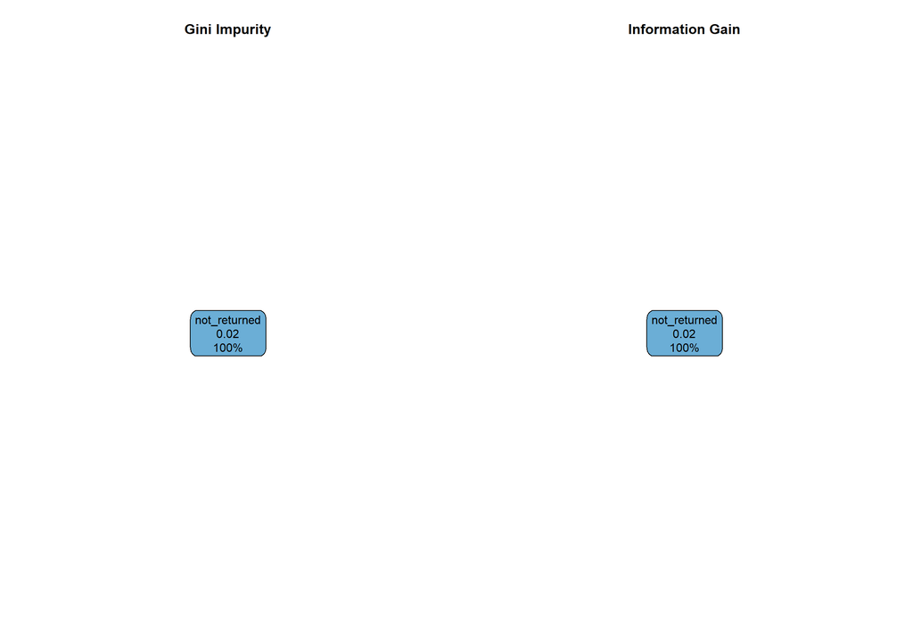

```r
# Plot trees
{par(mfrow = c(1,2))
rpart.plot(model_tree_gini, type = 4, main = "Gini Impurity")
rpart.plot(model_tree_info, type = 4, main = "Information Gain")}
```

```r
# Print models
print(model_tree_gini)
```

```
## n= 33837
##
## node), split, n, loss, yval, (yprob)
##       * denotes terminal node
##
## 1) root 33837 528 not_returned (0.98439578 0.01560422) *
```

```r
print(model_tree_info)
```

```
## n= 33837
##
## node), split, n, loss, yval, (yprob)
##       * denotes terminal node
##
## 1) root 33837 528 not_returned (0.98439578 0.01560422) *
```

```r
# Summarise models
summary(model_tree_gini)
```

```
## Call:
## rpart(formula = target ~ ., data = train_set, parms = list(split = "gini"))
##   n= 33837
##
##            CP nsplit rel error xerror xstd
## 1 0.005681818      0         1      0    0
##
## Node number 1: 33837 observations
##   predicted class=not_returned  expected loss=0.01560422  P(node) =1
##     class counts: 33309   528
##    probabilities: 0.984 0.016
```

```r
summary(model_tree_info)
```

```
## Call:
## rpart(formula = target ~ ., data = train_set, parms = list(split = "information"))
##   n= 33837
##
##   CP nsplit rel error xerror xstd
## 1  0      0         1      0    0
##
## Node number 1: 33837 observations
##   predicted class=not_returned  expected loss=0.01560422  P(node) =1
##     class counts: 33309   528
##    probabilities: 0.984 0.016
```

**Comments:** . Both Gini impurity and information gain produced identical decision trees in this case, with the same splitting criterion and resulting child nodes.

# 6. Create RF

### 6.1. Fit Random forest model

```r
# Random Forest ----------------------------------
metric <- "ROC"
control <- trainControl(method = "repeatedcv",
                        number = 5, # number of folds
                        repeats = 3, # number of repetitions
                        summaryFunction = twoClassSummary,
                        classProbs = TRUE,
                        savePredictions = TRUE)

# Learn Random Forest (rf)
set.seed(seed)
model_RF <- train(target ~ .,
                  data = train_set,
                  method = "rf",  # Random Forests
                  metric = metric,
                  trControl = control)



# Inspect model:---------------------------------------------------
print(model_RF)
```

```
## Random Forest
##
## 33837 samples
##    19 predictor
##     2 classes: 'not_returned', 'returned'
##
## No pre-processing
## Resampling: Cross-Validated (5 fold, repeated 3 times)
## Summary of sample sizes: 27070, 27069, 27070, 27070, 27069, 27070, ...
## Resampling results across tuning parameters:
##
##   mtry  ROC        Sens       Spec
##    2    0.5527601  1.0000000  0.00000000
##   10    0.5302722  0.9996297  0.01325547
##   19    0.5290804  0.9993996  0.01388440
##
## ROC was used to select the optimal model using the largest value.
## The final value used for the model was mtry = 2.
```

```r
# Check mtry parameter used for trained model
# getModelInfo(model_RF)$rf$parameters
print(model_RF$results$mtry)
```

```
## [1]  2 10 19
```

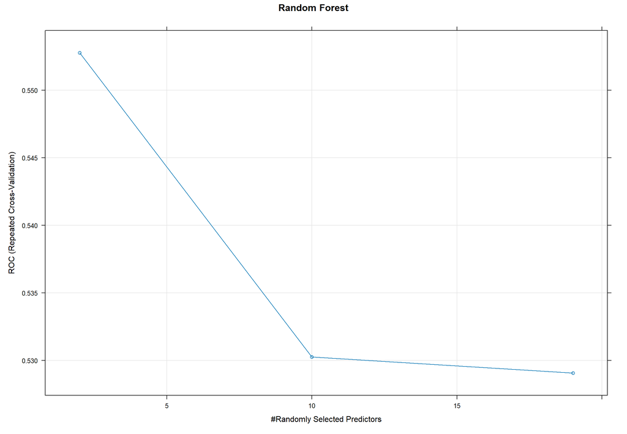

```r
# Plot ROC vs used parameters for model
plot(model_RF, main = "Random Forest")
```

**Comments:**

. Although Sensitivity value was good, ROC and Specificity values was very poor. . Despite being able to detect true positives (costumers who did not buy again), it fails to detect true negatives (costumers who bought again).

### 6.2. Validate results with a Confusion Matrix

```r
# Validate results with a Confusion Matrix --------------------------------

# Estimate performance of Random Forest on the TEST dataset
predictions_prob <- predict(model_RF, test_set, type = "prob")
head(predictions_prob)
```

```
##    not_returned returned
## 2         1.000    0.000
## 4         1.000    0.000
## 9         0.990    0.010
## 10        0.994    0.006
## 11        1.000    0.000
## 13        1.000    0.000
```

```r
predictions_raw <- predict(model_RF, test_set, type = "raw")
head(cbind(predictions_prob, predictions_raw))
```

```
##    not_returned returned predictions_raw
## 2         1.000    0.000    not_returned
## 4         1.000    0.000    not_returned
## 9         0.990    0.010    not_returned
## 10        0.994    0.006    not_returned
## 11        1.000    0.000    not_returned
## 13        1.000    0.000    not_returned
```

```r
# Confusion Matrix
confusionMatrix(data = predictions_raw,
                reference = test_set$target)
```

```
## Confusion Matrix and Statistics
##
##               Reference
## Prediction     not_returned returned
##   not_returned         8327      131
##   returned                0        0
##
##                Accuracy : 0.9845
##                  95% CI : (0.9816, 0.987)
##     No Information Rate : 0.9845
##     P-Value [Acc > NIR] : 0.5232
##
##                   Kappa : 0
##
##  Mcnemar's Test P-Value : <2e-16
##
##             Sensitivity : 1.0000
##             Specificity : 0.0000
##          Pos Pred Value : 0.9845
##          Neg Pred Value :    NaN
##              Prevalence : 0.9845
##          Detection Rate : 0.9845
##    Detection Prevalence : 1.0000
##       Balanced Accuracy : 0.5000
##
##        'Positive' Class : not_returned
##
```

**Comments:** . Confusion matrix - The model was able to predict correctly the costumers who did not return again in 8327 out of 8327 total cases. . Validation - Good Accuracy and Sensitivity values, but low Specificity value. . Despite being able to detect true positives (costumers who did not buy again), it fails to detect true negatives (costumers who bought again). . The model might be biased towards the majority class, resulting from class imbalance.

### 6.3. Plot

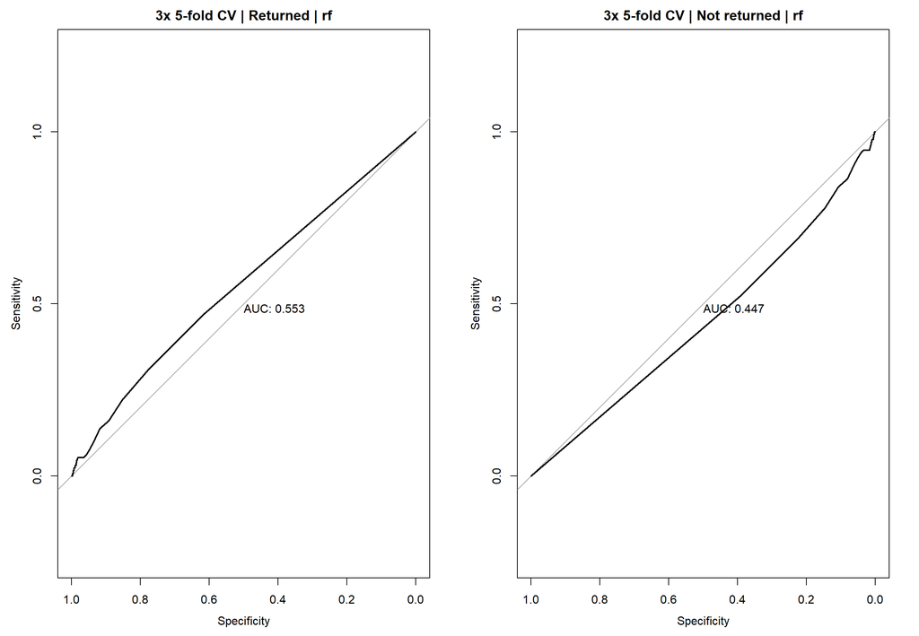

```r
par(mfrow = c(1, 2))
pROC::plot.roc(x = test_set$target,
         predictor = predictions_prob$returned,
         main = paste0(control$repeats, "x ", control$number, "-fold CV | Returned | ", model_RF$method),
         print.auc = TRUE)
pROC::plot.roc(x = test_set$target,
         predictor = predictions_prob$not_returned,
         main = paste0(control$repeats, "x ", control$number, "-fold CV | Not returned | ", model_RF$method),
         print.auc = TRUE)
```

```r
par(mfrow = c(1, 1))
```

**Comments:** . Returned - AUC was very poor. . Not returned - AUC value shows that model’s performance is worse than random guessing.

# 7. Oversampling method for returned customers

### 7.1. Apply SMOTE for imbalanced data

```r
# Since we have high imbalanced data, we will try to use an oversampling approach on the minority class

# Apply SMOTE technique
data_train_smote <- SMOTE(X = train_set[,-1],
                          target = train_set[,1],
                          K = 5,
                          dup_size = 30)
# K - number of nearest neighbors to consider when generating synthetic samples
# dup_size - number of number of synthetic samples to generate for each minority class instance


data_train_smote <- data_train_smote$data # extract only the balanced dataset
data_train_smote$class <- as.factor(data_train_smote$class)

# Check class distribution after applying SMOTE

prop.table(table(data_train_smote$class))
```

```
##
## not_returned     returned
##    0.6705115    0.3294885
```

**Comments:** . After SMOTE we get a 67/33 distribution for not returned/returned customers.

# 8. Create DT for oversampling data

### 8.1. Fit Decision Tree model using oversampling data

```r
#' Model Decision Tree from Rpart using oversampling data
model_tree_smote <- rpart(class ~ ., data = data_train_smote)
print(model_tree_smote)
```

```
## n= 49677
##
## node), split, n, loss, yval, (yprob)
##       * denotes terminal node
##
##    1) root 49677 16368 not_returned (0.67051150 0.32948850)
##      2) customer_stateSP< 2.675725e-05 25693  5391 not_returned (0.79017631 0.20982369)
##        4) F< 1.000423 24382  4603 not_returned (0.81121319 0.18878681)
##          8) payment_typecredit_card< 1.70907e-05 4896   217 not_returned (0.95567810 0.04432190) *
##          9) payment_typecredit_card>=1.70907e-05 19486  4386 not_returned (0.77491532 0.22508468)
##           18) payment_typecredit_card>=0.9997118 17951  2851 not_returned (0.84117876 0.15882124)
##             36) R< 1.001758 3972   130 not_returned (0.96727090 0.03272910) *
##             37) R>=1.001758 13979  2721 not_returned (0.80535088 0.19464912)
##               74) R>=1.995318 13486  2228 not_returned (0.83479164 0.16520836)
##                148) R>=3.998846 3981   205 not_returned (0.94850540 0.05149460) *
##                149) R< 3.998846 9505  2023 not_returned (0.78716465 0.21283535)
##                  298) R< 3.000009 8879  1397 not_returned (0.84266246 0.15733754)
##                    596) R>=2.999174 3922   237 not_returned (0.93957165 0.06042835) *
##                    597) R< 2.999174 4957  1160 not_returned (0.76598749 0.23401251)
##                     1194) R< 2.001483 4063   266 not_returned (0.93453113 0.06546887) *
##                     1195) R>=2.001483 894     0 returned (0.00000000 1.00000000) *
##                  299) R>=3.000009 626     0 returned (0.00000000 1.00000000) *
##               75) R< 1.995318 493     0 returned (0.00000000 1.00000000) *
##           19) payment_typecredit_card< 0.9997118 1535     0 returned (0.00000000 1.00000000) *
##        5) F>=1.000423 1311   523 returned (0.39893211 0.60106789)
##         10) F>=1.999783 721   198 not_returned (0.72538141 0.27461859) *
##         11) F< 1.999783 590     0 returned (0.00000000 1.00000000) *
##      3) customer_stateSP>=2.675725e-05 23984 10977 not_returned (0.54231988 0.45768012)
##        6) customer_stateSP>=0.9999977 16429  3422 not_returned (0.79170978 0.20829022)
##         12) order_delivered< 1.000039 13146  2098 not_returned (0.84040773 0.15959227)
##           24) R>=3.999236 2712    59 not_returned (0.97824484 0.02175516) *
##           25) R< 3.999236 10434  2039 not_returned (0.80458118 0.19541882)
##             50) R< 3.003368 10066  1671 not_returned (0.83399563 0.16600437) *
##             51) R>=3.003368 368     0 returned (0.00000000 1.00000000) *
##         13) order_delivered>=1.000039 3283  1324 not_returned (0.59671033 0.40328967)
##           26) order_delivered>=1.999318 2511   552 not_returned (0.78016726 0.21983274) *
##           27) order_delivered< 1.999318 772     0 returned (0.00000000 1.00000000) *
##        7) customer_stateSP< 0.9999977 7555     0 returned (0.00000000 1.00000000) *
```

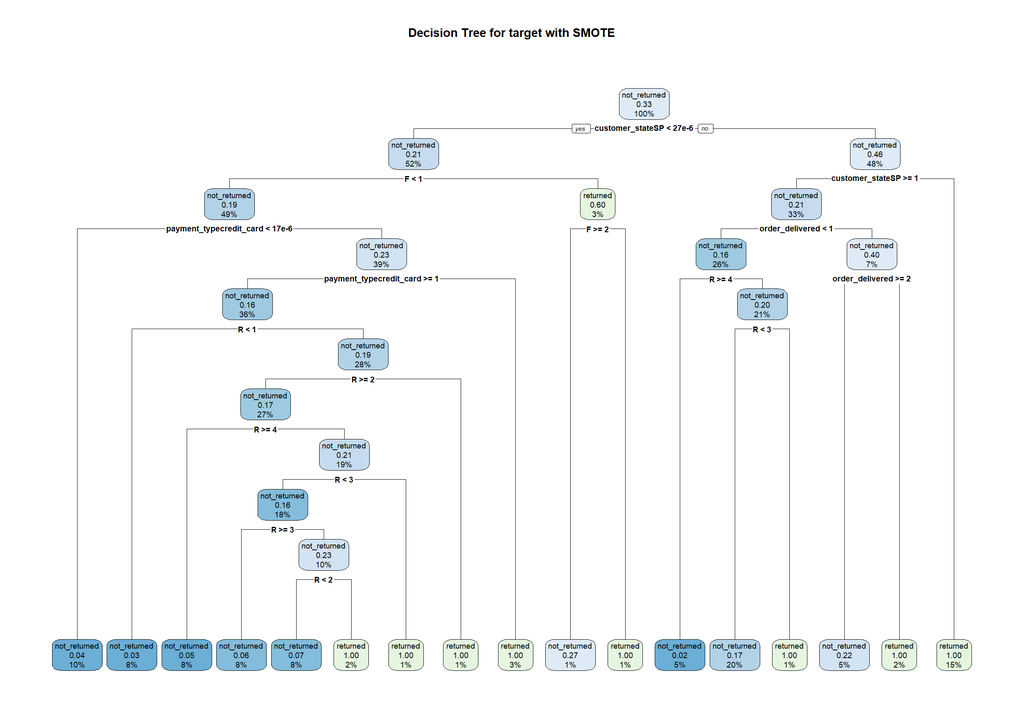

```r
#' View decision tree
rpart.plot(model_tree_smote,
           main = "Decision Tree for target with SMOTE")
```

### 8.2. Validate results with a Confusion Matrix

```r
#' Calculate model predictions on TEST set
prediction.dt_smote <- predict(model_tree_smote,
                         test_set,
                         type = "class")
head(prediction.dt_smote)
```

```
##            2            4            9           10           11           13
## not_returned not_returned not_returned not_returned not_returned not_returned
## Levels: not_returned returned
```

```r
test_set$prediction <- prediction.dt_smote

head(prediction.dt_smote)
```

```
##            2            4            9           10           11           13
## not_returned not_returned not_returned not_returned not_returned not_returned
## Levels: not_returned returned
```

```r
confusionMatrix(data = prediction.dt_smote,
                reference = test_set$target)
```

```
## Confusion Matrix and Statistics
##
##               Reference
## Prediction     not_returned returned
##   not_returned         8327      131
##   returned                0        0
##
##                Accuracy : 0.9845
##                  95% CI : (0.9816, 0.987)
##     No Information Rate : 0.9845
##     P-Value [Acc > NIR] : 0.5232
##
##                   Kappa : 0
##
##  Mcnemar's Test P-Value : <2e-16
##
##             Sensitivity : 1.0000
##             Specificity : 0.0000
##          Pos Pred Value : 0.9845
##          Neg Pred Value :    NaN
##              Prevalence : 0.9845
##          Detection Rate : 0.9845
##    Detection Prevalence : 1.0000
##       Balanced Accuracy : 0.5000
##
##        'Positive' Class : not_returned
##
```

**Comments:** . Confusion matrix - The model was able to predict correctly the costumers who did not buy again in 8327 out of 8327 total cases. . Despite being able to detect true positives (costumers who did not buy again), it fails to detect true negatives (costumers who bought again).

### 8.3. Compare Gini Impurity vs Information Gain

```r
# Compare Gini Impurity vs Information Gain -------------------------------

# Learn tree with Gini Impurity
model_tree_gini_smote <- rpart(class ~.,
                         data = data_train_smote,
                         parms = list(split = "gini"))

# Learn tree with Information Gain
model_tree_info_smote <- rpart(class ~.,
                         data = data_train_smote,
                         parms = list(split = "information"))
```

### 8.4. Plot trees

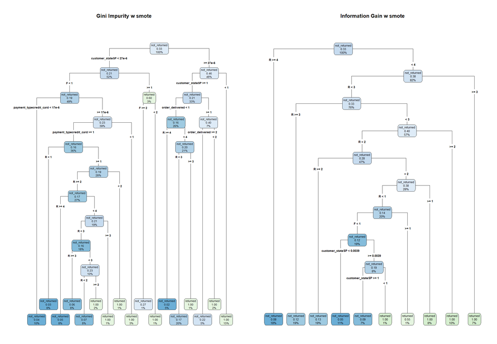

```r
{par(mfrow = c(1,2))
rpart.plot(model_tree_gini_smote, type = 4, main = "Gini Impurity w smote")
rpart.plot(model_tree_info_smote, type = 4, main = "Information Gain w smote")}
```

```r
# Print models
print(model_tree_gini_smote)
```

```
## n= 49677
##
## node), split, n, loss, yval, (yprob)
##       * denotes terminal node
##
##    1) root 49677 16368 not_returned (0.67051150 0.32948850)
##      2) customer_stateSP< 2.675725e-05 25693  5391 not_returned (0.79017631 0.20982369)
##        4) F< 1.000423 24382  4603 not_returned (0.81121319 0.18878681)
##          8) payment_typecredit_card< 1.70907e-05 4896   217 not_returned (0.95567810 0.04432190) *
##          9) payment_typecredit_card>=1.70907e-05 19486  4386 not_returned (0.77491532 0.22508468)
##           18) payment_typecredit_card>=0.9997118 17951  2851 not_returned (0.84117876 0.15882124)
##             36) R< 1.001758 3972   130 not_returned (0.96727090 0.03272910) *
##             37) R>=1.001758 13979  2721 not_returned (0.80535088 0.19464912)
##               74) R>=1.995318 13486  2228 not_returned (0.83479164 0.16520836)
##                148) R>=3.998846 3981   205 not_returned (0.94850540 0.05149460) *
##                149) R< 3.998846 9505  2023 not_returned (0.78716465 0.21283535)
##                  298) R< 3.000009 8879  1397 not_returned (0.84266246 0.15733754)
##                    596) R>=2.999174 3922   237 not_returned (0.93957165 0.06042835) *
##                    597) R< 2.999174 4957  1160 not_returned (0.76598749 0.23401251)
##                     1194) R< 2.001483 4063   266 not_returned (0.93453113 0.06546887) *
##                     1195) R>=2.001483 894     0 returned (0.00000000 1.00000000) *
##                  299) R>=3.000009 626     0 returned (0.00000000 1.00000000) *
##               75) R< 1.995318 493     0 returned (0.00000000 1.00000000) *
##           19) payment_typecredit_card< 0.9997118 1535     0 returned (0.00000000 1.00000000) *
##        5) F>=1.000423 1311   523 returned (0.39893211 0.60106789)
##         10) F>=1.999783 721   198 not_returned (0.72538141 0.27461859) *
##         11) F< 1.999783 590     0 returned (0.00000000 1.00000000) *
##      3) customer_stateSP>=2.675725e-05 23984 10977 not_returned (0.54231988 0.45768012)
##        6) customer_stateSP>=0.9999977 16429  3422 not_returned (0.79170978 0.20829022)
##         12) order_delivered< 1.000039 13146  2098 not_returned (0.84040773 0.15959227)
##           24) R>=3.999236 2712    59 not_returned (0.97824484 0.02175516) *
##           25) R< 3.999236 10434  2039 not_returned (0.80458118 0.19541882)
##             50) R< 3.003368 10066  1671 not_returned (0.83399563 0.16600437) *
##             51) R>=3.003368 368     0 returned (0.00000000 1.00000000) *
##         13) order_delivered>=1.000039 3283  1324 not_returned (0.59671033 0.40328967)
##           26) order_delivered>=1.999318 2511   552 not_returned (0.78016726 0.21983274) *
##           27) order_delivered< 1.999318 772     0 returned (0.00000000 1.00000000) *
##        7) customer_stateSP< 0.9999977 7555     0 returned (0.00000000 1.00000000) *
```

```r
print(model_tree_info_smote)
```

```
## n= 49677
##
## node), split, n, loss, yval, (yprob)
##       * denotes terminal node
##
##   1) root 49677 16368 not_returned (0.67051150 0.32948850)
##     2) R>=3.999546 8921   701 not_returned (0.92142137 0.07857863) *
##     3) R< 3.999546 40756 15667 not_returned (0.61559034 0.38440966)
##       6) R< 3.000009 37514 12425 not_returned (0.66879032 0.33120968)
##        12) R>=2.999946 9317  1081 not_returned (0.88397553 0.11602447) *
##        13) R< 2.999946 28197 11344 not_returned (0.59768770 0.40231230)
##          26) R< 2.000017 23406  6553 not_returned (0.72002905 0.27997095)
##            52) R>=1.999961 9540  1216 not_returned (0.87253669 0.12746331) *
##            53) R< 1.999961 13866  5337 not_returned (0.61510169 0.38489831)
##             106) R< 1.000007 9914  1385 not_returned (0.86029857 0.13970143)
##               212) F< 1.000853 9370  1086 not_returned (0.88409819 0.11590181)
##                 424) customer_stateSP< 0.003907043 5231   284 not_returned (0.94570828 0.05429172) *
##                 425) customer_stateSP>=0.003907043 4139   802 not_returned (0.80623339 0.19376661)
##                   850) customer_stateSP>=0.9992318 3653   316 not_returned (0.91349576 0.08650424) *
##                   851) customer_stateSP< 0.9992318 486     0 returned (0.00000000 1.00000000) *
##               213) F>=1.000853 544   245 returned (0.45036765 0.54963235) *
##             107) R>=1.000007 3952     0 returned (0.00000000 1.00000000) *
##          27) R>=2.000017 4791     0 returned (0.00000000 1.00000000) *
##       7) R>=3.000009 3242     0 returned (0.00000000 1.00000000) *
```

```r
# Summarise models
summary(model_tree_gini_smote)
```

```
## Call:
## rpart(formula = class ~ ., data = data_train_smote, parms = list(split = "gini"))
##   n= 49677
##
##           CP nsplit rel error    xerror        xstd
## 1 0.23078568      0 1.0000000 1.0000000 0.006400373
## 2 0.03665689      2 0.5384286 0.5253543 0.005151756
## 3 0.02358260      5 0.4284580 0.4280303 0.004739453
## 4 0.01985582      7 0.3812928 0.3721896 0.004466581
## 5 0.01505987      8 0.3614370 0.3459800 0.004327583
## 6 0.01124145     14 0.2384531 0.2573314 0.003793233
## 7 0.01000000     16 0.2159702 0.2234848 0.003556454
##
## Variable importance
##        customer_stateSP                       R payment_typecredit_card
##                      34                      16                      11
##      payment_typeboleto        customer_stateRJ        customer_stateMG
##                       9                       8                       7
##                       F         order_delivered       max_delivery_days
##                       6                       6                       2
##           payment_value
##                       1
##
## Node number 1: 49677 observations,    complexity param=0.2307857
##   predicted class=not_returned  expected loss=0.3294885  P(node) =1
##     class counts: 33309 16368
##    probabilities: 0.671 0.329
##   left son=2 (25693 obs) right son=3 (23984 obs)
##   Primary splits:
##       customer_stateSP        < 2.675725e-05 to the left,  improve=1524.093, (0 missing)
##       order_delivered         < 1.000039     to the left,  improve=1517.928, (0 missing)
##       R                       < 3.999546     to the right, improve=1369.124, (0 missing)
##       F                       < 1.000423     to the left,  improve=1356.736, (0 missing)
##       payment_typecredit_card < 1.70907e-05  to the left,  improve=1164.837, (0 missing)
##   Surrogate splits:
##       max_delivery_days < 9.999959     to the right, agree=0.669, adj=0.314, (0 split)
##       customer_stateRJ  < 0.9893281    to the right, agree=0.584, adj=0.139, (0 split)
##       customer_stateMG  < 0.1518336    to the right, agree=0.574, adj=0.118, (0 split)
##       payment_value     < 62.88446     to the right, agree=0.557, adj=0.083, (0 split)
##       order_delivered   < 1.001567     to the left,  agree=0.545, adj=0.058, (0 split)
```

[output cut: 303 more lines]

```
##       order_delivered         < 1.000413     to the left,  improve=  59.86123, (0 missing)
##       cat_ut_domesticas       < 0.001543489  to the left,  improve=  56.32264, (0 missing)
##   Surrogate splits:
##       payment_typeboleto < 0.01615801   to the left,  agree=0.828, adj=0.044, (0 split)
##       cat_ut_domesticas  < 1.008184     to the left,  agree=0.820, adj=0.002, (0 split)
##
## Node number 1194: 4063 observations
##   predicted class=not_returned  expected loss=0.06546887  P(node) =0.08178835
##     class counts:  3797   266
##    probabilities: 0.935 0.065
##
## Node number 1195: 894 observations
##   predicted class=returned      expected loss=0  P(node) =0.01799626
##     class counts:     0   894
##    probabilities: 0.000 1.000
```

```r
summary(model_tree_info_smote)
```

```
## Call:
## rpart(formula = class ~ ., data = data_train_smote, parms = list(split = "information"))
##   n= 49677
##
##           CP nsplit rel error    xerror        xstd
## 1 0.09903470      0 1.0000000 1.0000000 0.006400373
## 2 0.01099707      6 0.2677786 0.2724218 0.003892253
## 3 0.01000000      9 0.2347874 0.2237903 0.003558690
##
## Variable importance
##                R customer_stateSP                F customer_stateRJ
##               87                6                3                2
## customer_stateMG
##                1
##
## Node number 1: 49677 observations,    complexity param=0.0990347
##   predicted class=not_returned  expected loss=0.3294885  P(node) =1
##     class counts: 33309 16368
##    probabilities: 0.671 0.329
##   left son=2 (8921 obs) right son=3 (40756 obs)
##   Primary splits:
##       R                       < 3.999546     to the right, improve=1879.358, (0 missing)
##       customer_stateSP        < 2.675725e-05 to the left,  improve=1748.554, (0 missing)
##       order_delivered         < 1.000039     to the left,  improve=1639.294, (0 missing)
##       payment_typecredit_card < 1.70907e-05  to the left,  improve=1565.989, (0 missing)
##       F                       < 1.000423     to the left,  improve=1430.715, (0 missing)
##   Surrogate splits:
##       max_delivery_days < 116          to the right, agree=0.821, adj=0.001, (0 split)
##       order_delivered   < 0.5          to the left,  agree=0.820, adj=0.000, (0 split)
##       cat_moveis_decor  < 10.5         to the right, agree=0.820, adj=0.000, (0 split)
##       cat_ut_domesticas < 5.5          to the right, agree=0.820, adj=0.000, (0 split)
##
## Node number 2: 8921 observations
##   predicted class=not_returned  expected loss=0.07857863  P(node) =0.1795801
##     class counts:  8220   701
##    probabilities: 0.921 0.079
##
## Node number 3: 40756 observations,    complexity param=0.0990347
##   predicted class=not_returned  expected loss=0.3844097  P(node) =0.8204199
##     class counts: 25089 15667
```

[output cut: 155 more lines]

```
##       max_delivery_days  < 7.005631     to the left,  improve= 92.54629, (0 missing)
##   Surrogate splits:
##       customer_stateRJ   < 0.002771976  to the left,  agree=0.921, adj=0.329, (0 split)
##       customer_stateMG   < 0.003081125  to the left,  agree=0.919, adj=0.313, (0 split)
##       cat_desporto_lazer < 2.026442     to the left,  agree=0.883, adj=0.002, (0 split)
##
## Node number 850: 3653 observations
##   predicted class=not_returned  expected loss=0.08650424  P(node) =0.07353504
##     class counts:  3337   316
##    probabilities: 0.913 0.087
##
## Node number 851: 486 observations
##   predicted class=returned      expected loss=0  P(node) =0.009783199
##     class counts:     0   486
##    probabilities: 0.000 1.000
```

**Comments:** . . Gini impurity and information gain produced different decision trees. . For Gini impurity the predictors variables Recency (R) >=2 and customer state from SP seems to be effective at distinguishing between the classes. Recency plays an important factor on predicting customers return. . For Information Gain the predictor variable recency (R) >= 1 & < 4 seems to be effective at distinguishing between the classes.

# 9. Create RF

### 9.1. Fit Random forest model

```r
# Random Forest ----------------------------------
metric <- "ROC"
control_smote <- trainControl(method = "repeatedcv",
                        number = 5, # number of folds
                        repeats = 3, # number of repetitions
                        summaryFunction = twoClassSummary,
                        classProbs = TRUE,
                        savePredictions = TRUE)

# Learn Random Forest (rf)
set.seed(seed)
model_RF_smote <- train(class ~ .,
                  data = data_train_smote,
                  method = "rf",  # Random Forests
                  metric = metric,
                  trControl = control_smote)



# Inspect model:
print(model_RF_smote)
```

```
## Random Forest
##
## 49677 samples
##    19 predictor
##     2 classes: 'not_returned', 'returned'
##
## No pre-processing
## Resampling: Cross-Validated (5 fold, repeated 3 times)
## Summary of sample sizes: 39742, 39741, 39742, 39742, 39741, 39741, ...
## Resampling results across tuning parameters:
##
##   mtry  ROC        Sens       Spec
##    2    0.9904412  0.9998599  0.8657135
##   10    0.9912376  0.9986190  0.9665607
##   19    0.9894632  0.9974181  0.9665200
##
## ROC was used to select the optimal model using the largest value.
## The final value used for the model was mtry = 10.
```

```r
# Check mtry parameter used for trained model
# getModelInfo(model_RF)$rf$parameters
print(model_RF_smote$results$mtry)
```

```
## [1]  2 10 19
```

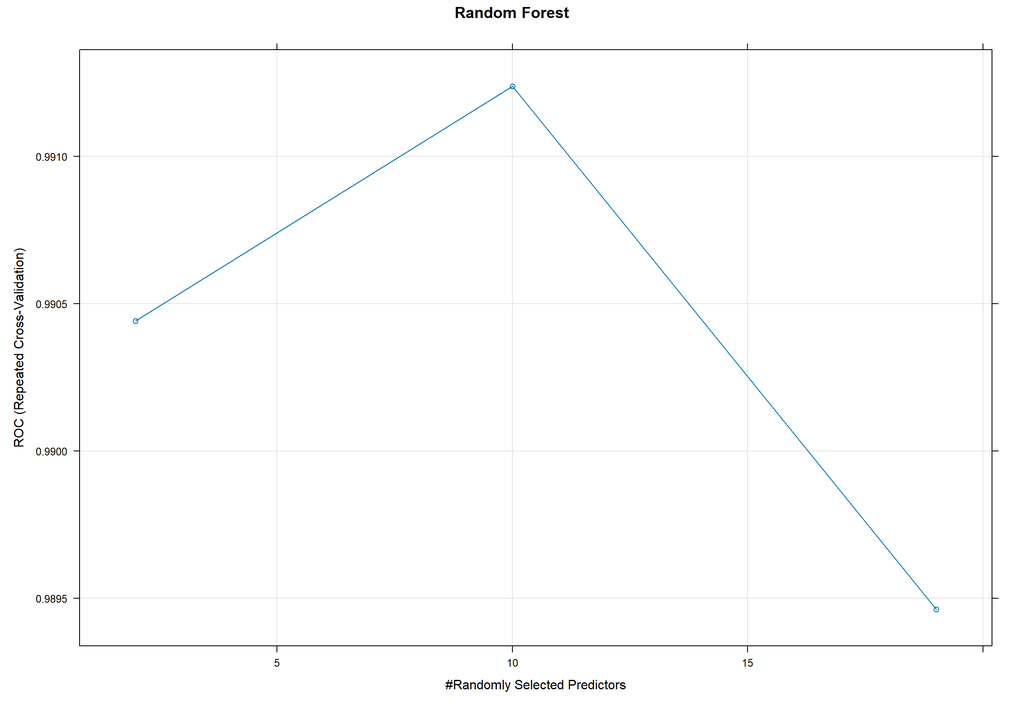

```r
# Plot ROC vs used parameters for model
plot(model_RF_smote, main = "Random Forest")
```

**Comments:**

### 9.2. Validate results with a Confusion Matrix

```r
# Validate results with a Confusion Matrix --------------------------------

# Estimate performance of Random Forest on the TEST dataset
predictions_prob_smote <- predict(model_RF_smote, test_set, type = "prob")
head(predictions_prob_smote)
```

```
##    not_returned returned
## 2         0.998    0.002
## 4         1.000    0.000
## 9         0.962    0.038
## 10        0.992    0.008
## 11        1.000    0.000
## 13        0.988    0.012
```

```r
predictions_raw_smote <- predict(model_RF_smote, test_set, type = "raw")
head(cbind(predictions_prob_smote, predictions_raw_smote))
```

```
##    not_returned returned predictions_raw_smote
## 2         0.998    0.002          not_returned
## 4         1.000    0.000          not_returned
## 9         0.962    0.038          not_returned
## 10        0.992    0.008          not_returned
## 11        1.000    0.000          not_returned
## 13        0.988    0.012          not_returned
```

```r
# Confusion Matrix
conf_matrix_rfsmote <- confusionMatrix(data = predictions_raw_smote,
                reference = test_set$target)


# Extract the confusion matrix table
conf_matrix_table_rfsmote <- as.data.frame(conf_matrix_rfsmote$table)
conf_matrix_table_rfsmote
```

```
##     Prediction    Reference Freq
## 1 not_returned not_returned 8319
## 2     returned not_returned    8
## 3 not_returned     returned  131
## 4     returned     returned    0
```

**Comments:** . Confusion matrix - The model was able to predict correctly the costumers who did not return again in 8319 out of 8327 total cases. . Validation - Good Accuracy and Sensitivity values, but low Specificity value. . Despite being able to detect true positives (costumers who did not buy again), it fails to detect true negatives (costumers who bought again). . The model might be over-fitted.

### 9.3. Plot

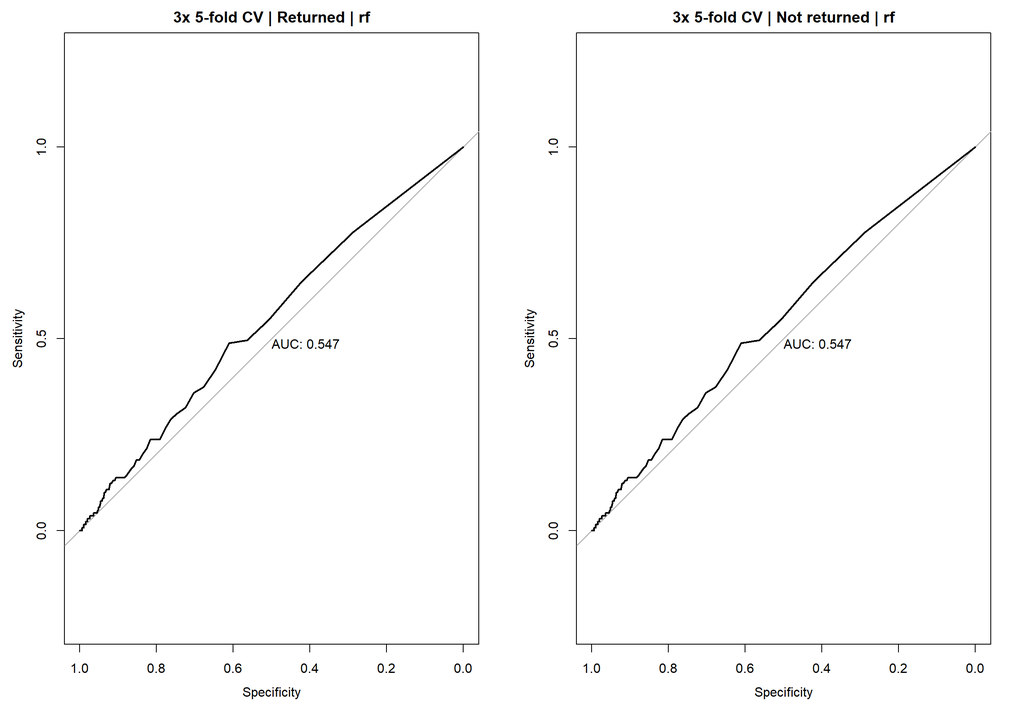

```r
par(mfrow = c(1, 2))
pROC::plot.roc(x = test_set$target,
         predictor = predictions_prob_smote$returned,
         main = paste0(control_smote$repeats, "x ", control_smote$number, "-fold CV | Returned | ", model_RF_smote$method),
         print.auc = TRUE)
pROC::plot.roc(x = test_set$target,
         predictor = predictions_prob_smote$not_returned,
         main = paste0(control_smote$repeats, "x ", control_smote$number, "-fold CV | Not returned | ", model_RF_smote$method),
         print.auc = TRUE)
```

```r
par(mfrow = c(1, 1))
```

**Comments:** . . Returned - AUC was very poor. . Not returned - AUC value was very poor.

# 10. SVM

### 10.1. Define SVM algorithm for imbalanced data

```r
set.seed(seed)
svm.imbdata.radial <- svm(target ~ .,
                   data = train_set,
                   kernel = "radial")

# summary
summary(svm.imbdata.radial)
```

```
##
## Call:
## svm(formula = target ~ ., data = train_set, kernel = "radial")
##
##
## Parameters:
##    SVM-Type:  C-classification
##  SVM-Kernel:  radial
##        cost:  1
##
## Number of Support Vectors:  3254
##
##  ( 2726 528 )
##
##
## Number of Classes:  2
##
## Levels:
##  not_returned returned
```

**Comments:** . All 4 kernels were used for SVM method, giving similar results. We chose to represent only the “radial” kernel.

### 10.2. Validate results with a Confusion Matrix

```r
# Predictions
svm.imbdata.pred.radial <- predict(svm.imbdata.radial, test_set)

# Confusion Matrix
confusionMatrix(data = svm.imbdata.pred.radial,
                reference = test_set$target)
```

```
## Confusion Matrix and Statistics
##
##               Reference
## Prediction     not_returned returned
##   not_returned         8327      131
##   returned                0        0
##
##                Accuracy : 0.9845
##                  95% CI : (0.9816, 0.987)
##     No Information Rate : 0.9845
##     P-Value [Acc > NIR] : 0.5232
##
##                   Kappa : 0
##
##  Mcnemar's Test P-Value : <2e-16
##
##             Sensitivity : 1.0000
##             Specificity : 0.0000
##          Pos Pred Value : 0.9845
##          Neg Pred Value :    NaN
##              Prevalence : 0.9845
##          Detection Rate : 0.9845
##    Detection Prevalence : 1.0000
##       Balanced Accuracy : 0.5000
##
##        'Positive' Class : not_returned
##
```

**Comments:** . Confusion matrix - The model was able to predict correctly the costumers who did not buy again in 8327 out of 8327 total cases. . Validation - Good Accuracy and Sensitivity values, but low Specificity value. . Despite being able to detect true positives (costumers who did not buy again), it fails to detect true negatives (costumers who bought again). . The model might be biased towards the majority class, resulting from class imbalance.

### 10.3. Define SVM algorithm for oversampling data

```r
# Define SVM algorithm using oversampling data

# Linear kernel
set.seed(seed)
svm.smote.lin <- svm(class ~ .,
                   data = data_train_smote,
                   kernel = "linear",
                   class.weights= c('not_returned'= 1, 'returned' = 1.4))

# Polynomial kernel
set.seed(seed)
svm.smote.poly <- svm(class ~ .,
                   data = data_train_smote,
                   kernel = "polynomial",
                   class.weights= c('not_returned'= 1, 'returned' = 1.4))

# Radial kernel
set.seed(seed)
svm.smote.rad <- svm(class ~ .,
                   data = data_train_smote,
                   kernel = "radial",
                   class.weights= c('not_returned'= 1, 'returned' = 1.4))

# Sigmoid kernel
set.seed(seed)
svm.smote.sig <- svm(class ~ .,
                   data = data_train_smote,
                   kernel = "sigmoid",
                   class.weights= c('not_returned'= 1, 'returned' = 1.4))


# summary
summary(svm.smote.lin)
```

```
##
## Call:
## svm(formula = class ~ ., data = data_train_smote, kernel = "linear",
##     class.weights = c(not_returned = 1, returned = 1.4))
##
##
## Parameters:
##    SVM-Type:  C-classification
##  SVM-Kernel:  linear
##        cost:  1
##
## Number of Support Vectors:  40011
##
##  ( 15349 24662 )
##
##
## Number of Classes:  2
##
## Levels:
##  not_returned returned
```

```r
summary(svm.smote.poly)
```

```
##
## Call:
## svm(formula = class ~ ., data = data_train_smote, kernel = "polynomial",
##     class.weights = c(not_returned = 1, returned = 1.4))
##
##
## Parameters:
##    SVM-Type:  C-classification
##  SVM-Kernel:  polynomial
##        cost:  1
##      degree:  3
##      coef.0:  0
##
## Number of Support Vectors:  25358
##
##  ( 10514 14844 )
##
##
## Number of Classes:  2
##
## Levels:
##  not_returned returned
```

```r
summary(svm.smote.rad)
```

```
##
## Call:
## svm(formula = class ~ ., data = data_train_smote, kernel = "radial",
##     class.weights = c(not_returned = 1, returned = 1.4))
##
##
## Parameters:
##    SVM-Type:  C-classification
##  SVM-Kernel:  radial
##        cost:  1
##
## Number of Support Vectors:  15824
##
##  ( 6472 9352 )
##
##
## Number of Classes:  2
##
## Levels:
##  not_returned returned
```

```r
summary(svm.smote.sig)
```

```
##
## Call:
## svm(formula = class ~ ., data = data_train_smote, kernel = "sigmoid",
##     class.weights = c(not_returned = 1, returned = 1.4))
##
##
## Parameters:
##    SVM-Type:  C-classification
##  SVM-Kernel:  sigmoid
##        cost:  1
##      coef.0:  0
##
## Number of Support Vectors:  24854
##
##  ( 10356 14498 )
##
##
## Number of Classes:  2
##
## Levels:
##  not_returned returned
```

### 10.4. Validate results with a Confusion Matrix

```r
# Predictions
svm.smote.pred.lin <- predict(svm.smote.lin, test_set)
svm.smote.pred.poly <- predict(svm.smote.poly, test_set)
svm.smote.pred.rad <- predict(svm.smote.rad, test_set)
svm.smote.pred.sig <- predict(svm.smote.sig, test_set)

# Get confusion matrix
conf_matrix_smote_lin <- confusionMatrix(data = svm.smote.pred.lin,
                               reference = test_set$target)

conf_matrix_smote_poly <- confusionMatrix(data = svm.smote.pred.poly,
                reference = test_set$target)

conf_matrix_smote_rad <- confusionMatrix(data = svm.smote.pred.rad,
                reference = test_set$target)

conf_matrix_smote_sig <- confusionMatrix(data = svm.smote.pred.sig,
                reference = test_set$target)

# Extract the confusion matrix table
conf_matrix_table_smote_lin <- as.data.frame(conf_matrix_smote_lin$table)
conf_matrix_table_smote_poly <- as.data.frame(conf_matrix_smote_poly$table)
conf_matrix_table_smote_rad <- as.data.frame(conf_matrix_smote_rad$table)
conf_matrix_table_smote_sig <- as.data.frame(conf_matrix_smote_sig$table)

conf_matrix_table_smote_lin
```

```
##     Prediction    Reference Freq
## 1 not_returned not_returned 8107
## 2     returned not_returned  220
## 3 not_returned     returned  120
## 4     returned     returned   11
```

```r
conf_matrix_table_smote_poly
```

```
##     Prediction    Reference Freq
## 1 not_returned not_returned 8066
## 2     returned not_returned  261
## 3 not_returned     returned  125
## 4     returned     returned    6
```

```r
conf_matrix_table_smote_rad
```

```
##     Prediction    Reference Freq
## 1 not_returned not_returned 8232
## 2     returned not_returned   95
## 3 not_returned     returned  129
## 4     returned     returned    2
```

```r
conf_matrix_table_smote_sig
```

```
##     Prediction    Reference Freq
## 1 not_returned not_returned 4919
## 2     returned not_returned 3408
## 3 not_returned     returned   68
## 4     returned     returned   63
```

**Comments:** . Confusion matrix - . The linear model was able to predict correctly the costumers who did not buy again in 8107 out of 8327 total cases and costumers who did bought again in only 11 out of 131 total cases. . The polynomial model was was able to predict correctly the costumers who did not buy again in 8066 out of 8327 total cases and costumers who did bought again in only 6 out of 131 total cases . . The radial model was was able to predict correctly the costumers who did not buy again in 8232 out of 8327 total cases and costumers who did bought again in only 2 out of 131 total cases. . The sigmoid model was was able to predict correctly the costumers who did not buy again in 4919 out of 8327 total cases and costumers who did bought again in 63 out of 131 total cases. . The sigmoid model performed better on predicting customers which returned compared to previous ones.

# 11. Compare different kernels of SVM and RF

```r
# metrics for RF
recall_rfsmote <- conf_matrix_rfsmote$byClass["Sensitivity"]
precision_rfsmote <- conf_matrix_rfsmote$byClass["Pos Pred Value"]
f_value_rfsmote <- (2 * precision_rfsmote * recall_rfsmote) / (precision_rfsmote + recall_rfsmote)
spec_rfsmote <- conf_matrix_rfsmote$byClass["Specificity"]

# metrics for linear model
recall_lin <- conf_matrix_smote_lin$byClass["Sensitivity"]
precision_lin <- conf_matrix_smote_lin$byClass["Pos Pred Value"]
f_value_lin <- (2 * precision_lin * recall_lin) / (precision_lin + recall_lin)
spec_lin <- conf_matrix_smote_lin$byClass["Specificity"]

# metrics for polynomial model
recall_poly <- conf_matrix_smote_poly$byClass["Sensitivity"]
precision_poly <- conf_matrix_smote_poly$byClass["Pos Pred Value"]
f_value_poly <- (2 * precision_poly * recall_poly) / (precision_poly + recall_poly)
spec_poly <- conf_matrix_smote_poly$byClass["Specificity"]

# metrics for radial model
recall_rad <- conf_matrix_smote_rad$byClass["Sensitivity"]
precision_rad <- conf_matrix_smote_rad$byClass["Pos Pred Value"]
f_value_rad <- (2 * precision_rad * recall_rad) / (precision_rad + recall_rad)
spec_rad <- conf_matrix_smote_rad$byClass["Specificity"]

# metrics for sigmoid model
recall_sig <- conf_matrix_smote_sig$byClass["Sensitivity"]
precision_sig <- conf_matrix_smote_sig$byClass["Pos Pred Value"]
f_value_sig <- (2 * precision_sig * recall_sig) / (precision_sig + recall_sig)
spec_sig <- conf_matrix_smote_sig$byClass["Specificity"]


# Summarize in table

models <- c("RF", "Linear", "Polynomial", "Radial", "Sigmoid")
recall <- c(recall_rfsmote, recall_lin, recall_poly, recall_rad, recall_sig)
precision <- c(precision_rfsmote, precision_lin, precision_poly, precision_rad, precision_sig)
F1_value <- c(f_value_rfsmote, f_value_lin, f_value_poly, f_value_rad, f_value_sig)
specificity <- c(spec_rfsmote, spec_lin, spec_poly, spec_rad, spec_sig)

metrics_df <- data.frame(Model = models, Recall = recall, Precision = precision, F1_Value = F1_value, Specificity = specificity)
metrics_df
```

```
##        Model    Recall Precision  F1_Value Specificity
## 1         RF 0.9990393 0.9844970 0.9917148  0.00000000
## 2     Linear 0.9735799 0.9854139 0.9794612  0.08396947
## 3 Polynomial 0.9686562 0.9847393 0.9766316  0.04580153
## 4     Radial 0.9885913 0.9845712 0.9865772  0.01526718
## 5    Sigmoid 0.5907290 0.9863645 0.7389214  0.48091603
```

**Comments:** . Both radial, polynomial and linear kernel’s consistently demonstrated strong performance in identifying customers who will not return (positive class), with high recall, precision, and F1 score. However, the specificity is extremely low for all cases ( < 10%), indicating a higher rate of false positives (customers who actually returned but the model predicted they would not).

. The sigmoid kernel exhibited a trade-off between sensitivity and specificity, with the lowest recall (59.07%) and F1 score (73.89%) among the models. While the specificity (48.09%) is higher compared to other models, indicating a lower rate of false positives, the challenges in capturing returning customers while maintaining precision are evident.

obs: Recall = Sensitivity, Precision = Pos Pred Value, F1 = mean of precision and recall. Lower F1 score indicates that both false positives and false negatives are impacting the model’s performance. Specificity = Prediction True Negatives

# 12. Overall Comment from this iteration